# Reproducible Research: Peer Assessment 1

## Loading and preprocessing the data

### To help preprocess the data for later analysis, the following packages will be loaded up:

```r
library(dplyr)
library(tidyr)
```

```r
library(ggplot2)
library(knitr)
```

### Reading in the data:

```r
setwd("D:/Classes/Data Science Track (Johns Hopkins)/05 Reproducible Research/Week 2/Peer Assesment 1/RepData_PeerAssessment1")
dat <- read.csv("activity.csv")
dat <- tbl_df(dat)
```

### Preprocessing the data to remove the >2,000 observations with NA for steps

```r
datClean <- filter(dat, !is.na(steps))
```

## What is mean total number of steps taken per day?

### Steps taken by day:

```r
steps <-
    datClean %>%
    select(steps:date) %>%
    group_by(date) %>%
    summarize(sum(steps))

print.data.frame(steps)
```

```
##          date sum(steps)
## 1  2012-10-02        126
## 2  2012-10-03      11352
## 3  2012-10-04      12116
## 4  2012-10-05      13294
## 5  2012-10-06      15420
## 6  2012-10-07      11015
## 7  2012-10-09      12811
## 8  2012-10-10       9900
## 9  2012-10-11      10304
## 10 2012-10-12      17382
## 11 2012-10-13      12426
## 12 2012-10-14      15098
## 13 2012-10-15      10139
## 14 2012-10-16      15084
```

[output cut: 39 more lines]

### Histogram showing the distribution and frequency of the total steps taken each day:

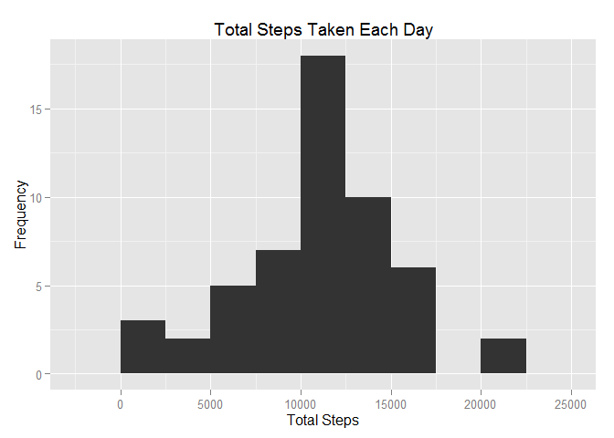

```r
qplot(steps$`sum(steps)`,
      data = steps,
      binwidth = 2500,
      xlab = "Total Steps",
      ylab = "Frequency",
      main = "Total Steps Taken Each Day")
```

### The mean and median of the total number of steps taken per day:

```r
stepsSum <-
    steps %>%
    summarize(Mean = mean(steps$`sum(steps)`), Median = median(steps$`sum(steps)`))

print(stepsSum)
```

```
## Source: local data frame [1 x 2]
##
##       Mean Median
##      (dbl)  (int)
## 1 10766.19  10765
```

## What is the average daily activity pattern?

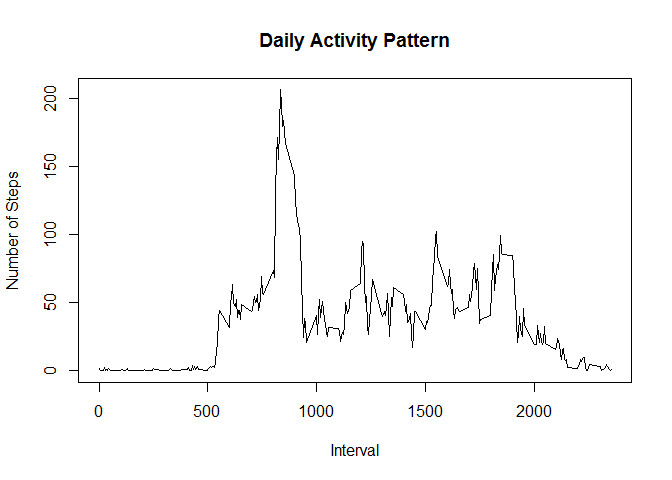

```r
byInterval <-
    datClean %>%
    select(-date) %>%
    group_by(interval) %>%
    summarize(mean = mean(steps))

plot(byInterval, type="l",
     xlab="Interval",
     ylab="Number of Steps",
     main="Daily Activity Pattern")
```

### Which 5-minute interval, on average across all the days in the dataset, contains the maximum number of steps?

```r
byInterval %>%
    filter(mean == max(mean)) %>%
    print
```

```
## Source: local data frame [1 x 2]
##
##   interval     mean
##      (int)    (dbl)
## 1      835 206.1698
```

## Imputing missing values

### Calculate and report the total number of missing values in the dataset (i.e. the total number of rows with NAs)

```r
missingValues <- filter(dat, is.na(steps))

sum(is.na(missingValues$steps))
```

```
## [1] 2304
```

### We’re going to fill in the missing 2,304 step observations by using the mean number of steps for that interval.

```r
imputedDat <- merge(dat, byInterval)
imputedDat$steps[is.na(imputedDat$steps)] <- imputedDat$mean[is.na(imputedDat$steps)]
```

### Histogram of the total number of steps taken each day

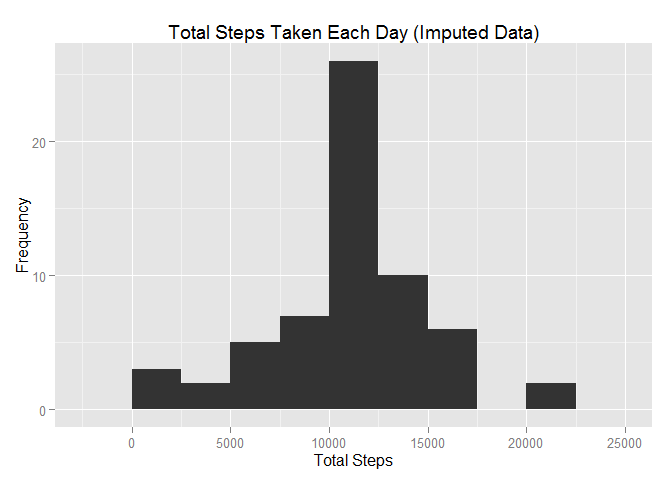

```r
imputedDatbyDay <-
    imputedDat %>%
    group_by(date) %>%
    summarize(sum(steps))

qplot(imputedDatbyDay$`sum(steps)`,
      binwidth = 2500,
      xlab = "Total Steps",
      ylab = "Frequency",
      main = "Total Steps Taken Each Day (Imputed Data)")
```

### Mean and median of the total number of steps taken per day when using the imputed data:

```r
imputedStepsSum <-
    imputedDatbyDay %>%
    summarize(Mean = mean(imputedDatbyDay$`sum(steps)`), Median = median(imputedDatbyDay$`sum(steps)`))

print(imputedStepsSum)
```

```
## Source: local data frame [1 x 2]
##
##       Mean   Median
##      (dbl)    (dbl)
## 1 10766.19 10766.19
```

### Impact of including imputed data

```r
meanChange <- stepsSum$Mean - imputedStepsSum$Mean
medianChange <- stepsSum$Median - imputedStepsSum$Median

print(meanChange)
```

```
## [1] 0
```

```r
print(medianChange)
```

```
## [1] -1.188679
```

## Are there differences in activity patterns between weekdays and weekends?

### Create new factor variable showing whether each day is a weekday or weekend

```r
imputedDatWeekday <- imputedDat
imputedDatWeekday$date <- as.Date(imputedDatWeekday$date)

# imputedDatWeekday %>%
#     mutate(DayOfWeek = ifelse(weekdays(date) == c("Saturday", "Sunday"), "Weekend", "Weekday"))

imputedDatWeekday <- mutate(imputedDatWeekday, DayOfWeek = ifelse(weekdays(date) == c("Saturday", "Sunday"), "Weekend", "Weekday"))
```

### Weekdays vs Weekends

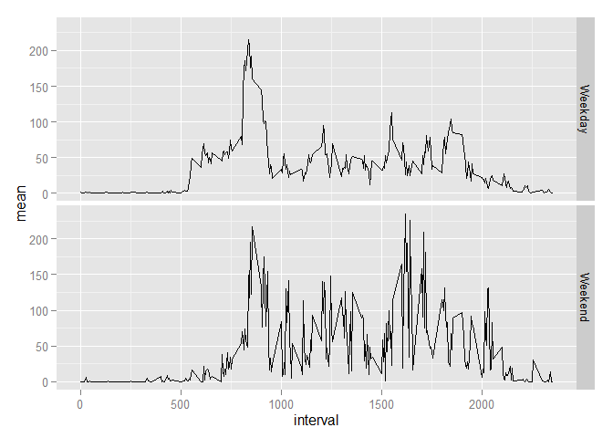

```r
imputedDatWeekdayInterval <-
    imputedDatWeekday %>%
    group_by(DayOfWeek, interval) %>%
    summarize(mean = mean(steps))

qplot(interval,
      mean,
      data = imputedDatWeekdayInterval,
      geom = "line") + facet_grid( DayOfWeek ~ .)
```